# R Notebook

```r
library(car)
library(tidyverse)
library(modelr)
library(GGally)
```

```r
houses_data <- read_csv("data/kc_house_data.csv")
```

```r
summary(houses_data)
```

```
      id                 date                         price            bedrooms        bathrooms      sqft_living
 Length:21613       Min.   :2014-05-02 00:00:00   Min.   :  75000   Min.   : 0.000   Min.   :0.000   Min.   :  290
 Class :character   1st Qu.:2014-07-22 00:00:00   1st Qu.: 321950   1st Qu.: 3.000   1st Qu.:1.750   1st Qu.: 1427
 Mode  :character   Median :2014-10-16 00:00:00   Median : 450000   Median : 3.000   Median :2.250   Median : 1910
                    Mean   :2014-10-29 04:38:01   Mean   : 540088   Mean   : 3.371   Mean   :2.115   Mean   : 2080
                    3rd Qu.:2015-02-17 00:00:00   3rd Qu.: 645000   3rd Qu.: 4.000   3rd Qu.:2.500   3rd Qu.: 2550
                    Max.   :2015-05-27 00:00:00   Max.   :7700000   Max.   :33.000   Max.   :8.000   Max.   :13540
    sqft_lot           floors        waterfront            view          condition         grade          sqft_above
 Min.   :    520   Min.   :1.000   Min.   :0.000000   Min.   :0.0000   Min.   :1.000   Min.   : 1.000   Min.   : 290
 1st Qu.:   5040   1st Qu.:1.000   1st Qu.:0.000000   1st Qu.:0.0000   1st Qu.:3.000   1st Qu.: 7.000   1st Qu.:1190
 Median :   7618   Median :1.500   Median :0.000000   Median :0.0000   Median :3.000   Median : 7.000   Median :1560
 Mean   :  15107   Mean   :1.494   Mean   :0.007542   Mean   :0.2343   Mean   :3.409   Mean   : 7.657   Mean   :1788
 3rd Qu.:  10688   3rd Qu.:2.000   3rd Qu.:0.000000   3rd Qu.:0.0000   3rd Qu.:4.000   3rd Qu.: 8.000   3rd Qu.:2210
 Max.   :1651359   Max.   :3.500   Max.   :1.000000   Max.   :4.0000   Max.   :5.000   Max.   :13.000   Max.   :9410
 sqft_basement       yr_built     yr_renovated       zipcode           lat             long        sqft_living15
 Min.   :   0.0   Min.   :1900   Min.   :   0.0   Min.   :98001   Min.   :47.16   Min.   :-122.5   Min.   : 399
 1st Qu.:   0.0   1st Qu.:1951   1st Qu.:   0.0   1st Qu.:98033   1st Qu.:47.47   1st Qu.:-122.3   1st Qu.:1490
 Median :   0.0   Median :1975   Median :   0.0   Median :98065   Median :47.57   Median :-122.2   Median :1840
 Mean   : 291.5   Mean   :1971   Mean   :  84.4   Mean   :98078   Mean   :47.56   Mean   :-122.2   Mean   :1987
 3rd Qu.: 560.0   3rd Qu.:1997   3rd Qu.:   0.0   3rd Qu.:98118   3rd Qu.:47.68   3rd Qu.:-122.1   3rd Qu.:2360
 Max.   :4820.0   Max.   :2015   Max.   :2015.0   Max.   :98199   Max.   :47.78   Max.   :-121.3   Max.   :6210
   sqft_lot15
 Min.   :   651
 1st Qu.:  5100
 Median :  7620
 Mean   : 12768
 3rd Qu.: 10083
 Max.   :871200
```

```r
glimpse(houses_data)
```

```
Rows: 21,613
Columns: 21
$ id            <chr> "7129300520", "6414100192", "5631500400", "2487200875", "1954400510", "7237550310", "1321400060", …
$ date          <dttm> 2014-10-13, 2014-12-09, 2015-02-25, 2014-12-09, 2015-02-18, 2014-05-12, 2014-06-27, 2015-01-15, 2…
$ price         <dbl> 221900, 538000, 180000, 604000, 510000, 1225000, 257500, 291850, 229500, 323000, 662500, 468000, 3…
$ bedrooms      <dbl> 3, 3, 2, 4, 3, 4, 3, 3, 3, 3, 3, 2, 3, 3, 5, 4, 3, 4, 2, 3, 4, 3, 5, 2, 3, 3, 3, 3, 3, 4, 3, 2, 4,…
$ bathrooms     <dbl> 1.00, 2.25, 1.00, 3.00, 2.00, 4.50, 2.25, 1.50, 1.00, 2.50, 2.50, 1.00, 1.00, 1.75, 2.00, 3.00, 2.…
$ sqft_living   <dbl> 1180, 2570, 770, 1960, 1680, 5420, 1715, 1060, 1780, 1890, 3560, 1160, 1430, 1370, 1810, 2950, 189…
$ sqft_lot      <dbl> 5650, 7242, 10000, 5000, 8080, 101930, 6819, 9711, 7470, 6560, 9796, 6000, 19901, 9680, 4850, 5000…
$ floors        <dbl> 1.0, 2.0, 1.0, 1.0, 1.0, 1.0, 2.0, 1.0, 1.0, 2.0, 1.0, 1.0, 1.5, 1.0, 1.5, 2.0, 2.0, 1.5, 1.0, 1.0…
$ waterfront    <dbl> 0, 0, 0, 0, 0, 0, 0, 0, 0, 0, 0, 0, 0, 0, 0, 0, 0, 0, 0, 0, 0, 0, 0, 0, 0, 0, 0, 0, 0, 0, 0, 0, 0,…
$ view          <dbl> 0, 0, 0, 0, 0, 0, 0, 0, 0, 0, 0, 0, 0, 0, 0, 3, 0, 0, 0, 0, 0, 4, 0, 0, 0, 0, 0, 0, 0, 0, 0, 0, 0,…
$ condition     <dbl> 3, 3, 3, 5, 3, 3, 3, 3, 3, 3, 3, 4, 4, 4, 3, 3, 3, 4, 4, 4, 4, 3, 3, 3, 4, 5, 3, 5, 3, 3, 3, 3, 4,…
$ grade         <dbl> 7, 7, 6, 7, 8, 11, 7, 7, 7, 7, 8, 7, 7, 7, 7, 9, 7, 7, 7, 7, 7, 9, 8, 7, 8, 6, 8, 8, 7, 8, 8, 7, 7…
$ sqft_above    <dbl> 1180, 2170, 770, 1050, 1680, 3890, 1715, 1060, 1050, 1890, 1860, 860, 1430, 1370, 1810, 1980, 1890…
$ sqft_basement <dbl> 0, 400, 0, 910, 0, 1530, 0, 0, 730, 0, 1700, 300, 0, 0, 0, 970, 0, 0, 0, 0, 760, 720, 0, 0, 0, 0, …
$ yr_built      <dbl> 1955, 1951, 1933, 1965, 1987, 2001, 1995, 1963, 1960, 2003, 1965, 1942, 1927, 1977, 1900, 1979, 19…
$ yr_renovated  <dbl> 0, 1991, 0, 0, 0, 0, 0, 0, 0, 0, 0, 0, 0, 0, 0, 0, 0, 0, 0, 0, 0, 0, 0, 0, 0, 0, 0, 0, 0, 0, 0, 0,…
$ zipcode       <dbl> 98178, 98125, 98028, 98136, 98074, 98053, 98003, 98198, 98146, 98038, 98007, 98115, 98028, 98074, …
$ lat           <dbl> 47.5112, 47.7210, 47.7379, 47.5208, 47.6168, 47.6561, 47.3097, 47.4095, 47.5123, 47.3684, 47.6007,…
$ long          <dbl> -122.257, -122.319, -122.233, -122.393, -122.045, -122.005, -122.327, -122.315, -122.337, -122.031…
$ sqft_living15 <dbl> 1340, 1690, 2720, 1360, 1800, 4760, 2238, 1650, 1780, 2390, 2210, 1330, 1780, 1370, 1360, 2140, 18…
$ sqft_lot15    <dbl> 5650, 7639, 8062, 5000, 7503, 101930, 6819, 9711, 8113, 7570, 8925, 6000, 12697, 10208, 4850, 4000…
```

# Tidy up the data ready for regression

```r
unique(houses_data$condition)
```

```
[1] 3 5 4 1 2
```

```r
unique(houses_data$grade)
```

```
 [1]  7  6  8 11  9  5 10 12  4  3 13  1
```

```r
unique(houses_data$view)
```

```
[1] 0 3 4 2 1
```

Removing date, id, sqft_living15, sqft_lot15 and zipcode Convert Waterfront to logical Converted yr_renovated into a renovated logical variable, indicating whether the property had ever been renovated. Convert condition and grade to factor because they are categorical

```r
houses_tidy <- houses_data %>%
  select(-c("id", "date", "sqft_living15", "sqft_lot15", "zipcode")) %>%
  mutate(waterfront = as.logical(waterfront)) %>%
  mutate(renovated = yr_renovated != 0) %>%
  select(-"yr_renovated") %>%
  mutate(condition = as_factor(condition)) %>%
  mutate(grade = as_factor(grade))

glimpse(houses_tidy)
```

```
Rows: 21,613
Columns: 16
$ price         <dbl> 221900, 538000, 180000, 604000, 510000, 1225000, 257500, 291850, 229500, 323000, 662500, 468000, 3…
$ bedrooms      <dbl> 3, 3, 2, 4, 3, 4, 3, 3, 3, 3, 3, 2, 3, 3, 5, 4, 3, 4, 2, 3, 4, 3, 5, 2, 3, 3, 3, 3, 3, 4, 3, 2, 4,…
$ bathrooms     <dbl> 1.00, 2.25, 1.00, 3.00, 2.00, 4.50, 2.25, 1.50, 1.00, 2.50, 2.50, 1.00, 1.00, 1.75, 2.00, 3.00, 2.…
$ sqft_living   <dbl> 1180, 2570, 770, 1960, 1680, 5420, 1715, 1060, 1780, 1890, 3560, 1160, 1430, 1370, 1810, 2950, 189…
$ sqft_lot      <dbl> 5650, 7242, 10000, 5000, 8080, 101930, 6819, 9711, 7470, 6560, 9796, 6000, 19901, 9680, 4850, 5000…
$ floors        <dbl> 1.0, 2.0, 1.0, 1.0, 1.0, 1.0, 2.0, 1.0, 1.0, 2.0, 1.0, 1.0, 1.5, 1.0, 1.5, 2.0, 2.0, 1.5, 1.0, 1.0…
$ waterfront    <lgl> FALSE, FALSE, FALSE, FALSE, FALSE, FALSE, FALSE, FALSE, FALSE, FALSE, FALSE, FALSE, FALSE, FALSE, …
$ view          <dbl> 0, 0, 0, 0, 0, 0, 0, 0, 0, 0, 0, 0, 0, 0, 0, 3, 0, 0, 0, 0, 0, 4, 0, 0, 0, 0, 0, 0, 0, 0, 0, 0, 0,…
$ condition     <fct> 3, 3, 3, 5, 3, 3, 3, 3, 3, 3, 3, 4, 4, 4, 3, 3, 3, 4, 4, 4, 4, 3, 3, 3, 4, 5, 3, 5, 3, 3, 3, 3, 4,…
$ grade         <fct> 7, 7, 6, 7, 8, 11, 7, 7, 7, 7, 8, 7, 7, 7, 7, 9, 7, 7, 7, 7, 7, 9, 8, 7, 8, 6, 8, 8, 7, 8, 8, 7, 7…
$ sqft_above    <dbl> 1180, 2170, 770, 1050, 1680, 3890, 1715, 1060, 1050, 1890, 1860, 860, 1430, 1370, 1810, 1980, 1890…
$ sqft_basement <dbl> 0, 400, 0, 910, 0, 1530, 0, 0, 730, 0, 1700, 300, 0, 0, 0, 970, 0, 0, 0, 0, 760, 720, 0, 0, 0, 0, …
$ yr_built      <dbl> 1955, 1951, 1933, 1965, 1987, 2001, 1995, 1963, 1960, 2003, 1965, 1942, 1927, 1977, 1900, 1979, 19…
$ lat           <dbl> 47.5112, 47.7210, 47.7379, 47.5208, 47.6168, 47.6561, 47.3097, 47.4095, 47.5123, 47.3684, 47.6007,…
$ long          <dbl> -122.257, -122.319, -122.233, -122.393, -122.045, -122.005, -122.327, -122.315, -122.337, -122.031…
$ renovated     <lgl> FALSE, TRUE, FALSE, FALSE, FALSE, FALSE, FALSE, FALSE, FALSE, FALSE, FALSE, FALSE, FALSE, FALSE, F…
```

Check for aliased variables using the alias() function (this takes in a formula object and a data set). [Hint - formula price ~ . says ‘price varying with all predictors’, this is a suitable input to alias()]. Remove variables that lead to an alias. Check the ‘Elements of multiple regression’ lesson for a dropdown containing further information on finding aliased variables in a dataset.

```r
alias(price ~ ., data = houses_tidy)
```

```
Model :
price ~ bedrooms + bathrooms + sqft_living + sqft_lot + floors +
    waterfront + view + condition + grade + sqft_above + sqft_basement +
    yr_built + lat + long + renovated

Complete :
              (Intercept) bedrooms bathrooms sqft_living sqft_lot floors waterfrontTRUE view condition2 condition3
sqft_basement  0           0        0         1           0        0      0              0    0          0
              condition4 condition5 grade3 grade4 grade5 grade6 grade7 grade8 grade9 grade10 grade11 grade12 grade13
sqft_basement  0          0          0      0      0      0      0      0      0      0       0       0       0
              sqft_above yr_built lat long renovatedTRUE
sqft_basement -1          0        0   0    0
```

The output says that sqft_basement can be calculated as intercept + sqft_living - sqft_above So we can drop sqft_basement

```r
houses_tidy <- houses_tidy %>%
  select(-c("sqft_basement"))

glimpse(houses_tidy)
```

```
Rows: 21,613
Columns: 15
$ price       <dbl> 221900, 538000, 180000, 604000, 510000, 1225000, 257500, 291850, 229500, 323000, 662500, 468000, 310…
$ bedrooms    <dbl> 3, 3, 2, 4, 3, 4, 3, 3, 3, 3, 3, 2, 3, 3, 5, 4, 3, 4, 2, 3, 4, 3, 5, 2, 3, 3, 3, 3, 3, 4, 3, 2, 4, 3…
$ bathrooms   <dbl> 1.00, 2.25, 1.00, 3.00, 2.00, 4.50, 2.25, 1.50, 1.00, 2.50, 2.50, 1.00, 1.00, 1.75, 2.00, 3.00, 2.00…
$ sqft_living <dbl> 1180, 2570, 770, 1960, 1680, 5420, 1715, 1060, 1780, 1890, 3560, 1160, 1430, 1370, 1810, 2950, 1890,…
$ sqft_lot    <dbl> 5650, 7242, 10000, 5000, 8080, 101930, 6819, 9711, 7470, 6560, 9796, 6000, 19901, 9680, 4850, 5000, …
$ floors      <dbl> 1.0, 2.0, 1.0, 1.0, 1.0, 1.0, 2.0, 1.0, 1.0, 2.0, 1.0, 1.0, 1.5, 1.0, 1.5, 2.0, 2.0, 1.5, 1.0, 1.0, …
$ waterfront  <lgl> FALSE, FALSE, FALSE, FALSE, FALSE, FALSE, FALSE, FALSE, FALSE, FALSE, FALSE, FALSE, FALSE, FALSE, FA…
$ view        <dbl> 0, 0, 0, 0, 0, 0, 0, 0, 0, 0, 0, 0, 0, 0, 0, 3, 0, 0, 0, 0, 0, 4, 0, 0, 0, 0, 0, 0, 0, 0, 0, 0, 0, 0…
$ condition   <fct> 3, 3, 3, 5, 3, 3, 3, 3, 3, 3, 3, 4, 4, 4, 3, 3, 3, 4, 4, 4, 4, 3, 3, 3, 4, 5, 3, 5, 3, 3, 3, 3, 4, 4…
$ grade       <fct> 7, 7, 6, 7, 8, 11, 7, 7, 7, 7, 8, 7, 7, 7, 7, 9, 7, 7, 7, 7, 7, 9, 8, 7, 8, 6, 8, 8, 7, 8, 8, 7, 7, …
$ sqft_above  <dbl> 1180, 2170, 770, 1050, 1680, 3890, 1715, 1060, 1050, 1890, 1860, 860, 1430, 1370, 1810, 1980, 1890, …
$ yr_built    <dbl> 1955, 1951, 1933, 1965, 1987, 2001, 1995, 1963, 1960, 2003, 1965, 1942, 1927, 1977, 1900, 1979, 1994…
$ lat         <dbl> 47.5112, 47.7210, 47.7379, 47.5208, 47.6168, 47.6561, 47.3097, 47.4095, 47.5123, 47.3684, 47.6007, 4…
$ long        <dbl> -122.257, -122.319, -122.233, -122.393, -122.045, -122.005, -122.327, -122.315, -122.337, -122.031, …
$ renovated   <lgl> FALSE, TRUE, FALSE, FALSE, FALSE, FALSE, FALSE, FALSE, FALSE, FALSE, FALSE, FALSE, FALSE, FALSE, FAL…
```

Systematically build a regression model containing up to four main effects (remember, a main effect is just a single predictor with coefficient), testing the regression diagnostics as you go

splitting datasets into numeric and non-numeric columns might help ggpairs() run in manageable time, although you will need to add either a price or resid column to the non-numeric dataframe in order to see its correlations with the non-numeric predictors.

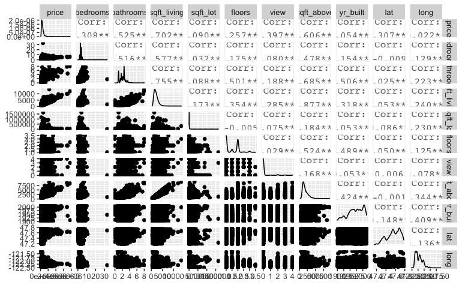

```r
houses_tidy_numeric <- houses_tidy %>%
  select_if(is.numeric)

ggpairs(houses_tidy_numeric)
```

Correlation of sqft_living with price looks pretty promising

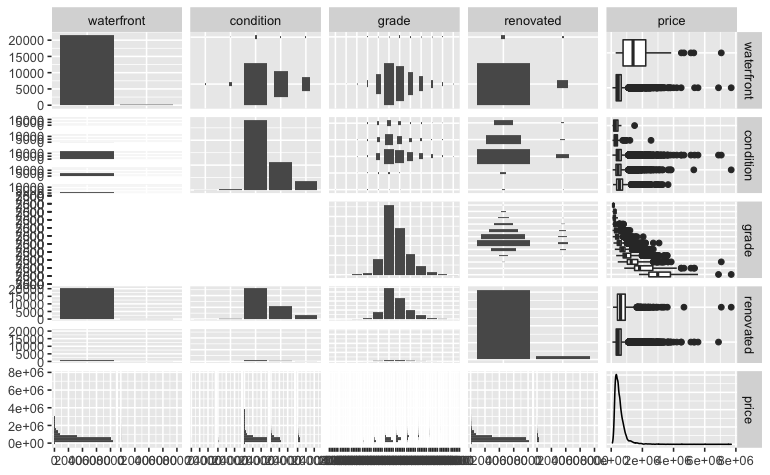

```r
houses_tidy_nonnumeric <- houses_tidy %>%
  select_if(function(x) !is.numeric(x))

houses_tidy_nonnumeric$price <- houses_tidy$price

ggpairs(houses_tidy_nonnumeric)
```

The split of price by grade and waterfront also look decent.

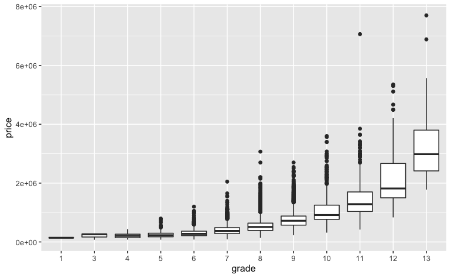

```r
houses_tidy %>%
  ggplot(aes(x = grade, y = price)) +
  geom_boxplot()
```

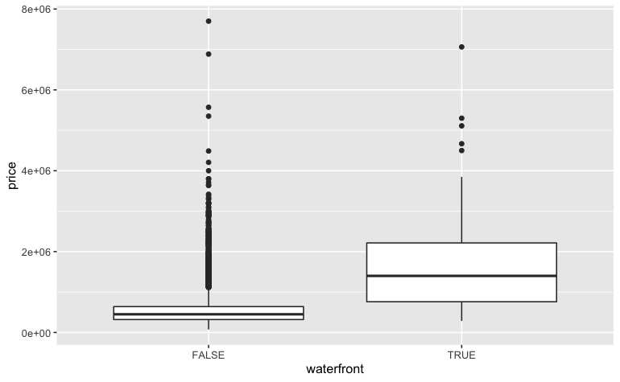

```r
houses_tidy %>%
  ggplot(aes(x = waterfront, y = price)) +
  geom_boxplot()
```

```r
gggpairs(housing_test)
ggpairs(housing_test1)
```

[output not shown]

The ggpairs plots reveal that sqft_living strongly corelated with price. Also, The split of price by grade appears to be strongly influenced.

FIRST PREDICTOR Now, lets start with sqft_living.

```r
mod1a <- lm(price ~ sqft_living, data = houses_tidy)
summary(mod1a)
```

```
Call:
lm(formula = price ~ sqft_living, data = houses_tidy)

Residuals:
     Min       1Q   Median       3Q      Max
-1476062  -147486   -24043   106182  4362067

Coefficients:
              Estimate Std. Error t value Pr(>|t|)
(Intercept) -43580.743   4402.690  -9.899   <2e-16 ***
sqft_living    280.624      1.936 144.920   <2e-16 ***
---
Signif. codes:  0 ‘***’ 0.001 ‘**’ 0.01 ‘*’ 0.05 ‘.’ 0.1 ‘ ’ 1

Residual standard error: 261500 on 21611 degrees of freedom
Multiple R-squared:  0.4929,    Adjusted R-squared:  0.4928
F-statistic: 2.1e+04 on 1 and 21611 DF,  p-value: < 2.2e-16
```

The regression equation is Price = -43580.7 + 280.6 * sqft_living

```r
mod1b <- lm(price ~ grade, data = houses_tidy)
summary(mod1b)
```

```
Call:
lm(formula = price ~ grade, data = houses_tidy)

Residuals:
     Min       1Q   Median       3Q      Max
-1929615  -135853   -35090    89080  5565658

Coefficients:
            Estimate Std. Error t value Pr(>|t|)
(Intercept)   142000     254499   0.558 0.576878
grade3         63667     293870   0.217 0.828484
grade4         72381     258849   0.280 0.779767
grade5        106524     255024   0.418 0.676169
grade6        159920     254561   0.628 0.529868
grade7        260590     254513   1.024 0.305904
grade8        400853     254520   1.575 0.115285
grade9        631513     254547   2.481 0.013112 *
grade10       929771     254611   3.652 0.000261 ***
grade11      1354842     254817   5.317 1.07e-07 ***
grade12      2049222     255909   8.008 1.23e-15 ***
grade13      3567615     264106  13.508  < 2e-16 ***
---
Signif. codes:  0 ‘***’ 0.001 ‘**’ 0.01 ‘*’ 0.05 ‘.’ 0.1 ‘ ’ 1

Residual standard error: 254500 on 21601 degrees of freedom
Multiple R-squared:  0.5197,    Adjusted R-squared:  0.5195
F-statistic:  2125 on 11 and 21601 DF,  p-value: < 2.2e-16
```

```r
mod1c <- lm(price ~ waterfront, data = houses_tidy)
summary(mod1c)
```

```
Call:
lm(formula = price ~ waterfront, data = houses_tidy)

Residuals:
     Min       1Q   Median       3Q      Max
-1376876  -211564   -81564   108436  7168436

Coefficients:
               Estimate Std. Error t value Pr(>|t|)
(Intercept)      531564       2416  220.00   <2e-16 ***
waterfrontTRUE  1130312      27822   40.63   <2e-16 ***
---
Signif. codes:  0 ‘***’ 0.001 ‘**’ 0.01 ‘*’ 0.05 ‘.’ 0.1 ‘ ’ 1

Residual standard error: 353900 on 21611 degrees of freedom
Multiple R-squared:  0.07095,   Adjusted R-squared:  0.07091
F-statistic:  1650 on 1 and 21611 DF,  p-value: < 2.2e-16
```

# grade looks the most promising, but some of the grade level coeffs are insignificant.

# the F-test at the bottom of the regression output tests against the null model (i.e. intercept only)

# but, if we want, we can replicate this using a separate anova

# null model: regress price on intercept only

```r
null_model <- lm(price ~ 1, data = houses_tidy)
grade_model <- lm(price ~ grade, data = houses_tidy)
anova(null_model, grade_model)
```

```
Analysis of Variance Table

Model 1: price ~ 1
Model 2: price ~ grade
  Res.Df        RSS Df  Sum of Sq      F    Pr(>F)
1  21612 2.9129e+15
2  21601 1.3991e+15 11 1.5138e+15 2124.8 < 2.2e-16 ***
---
Signif. codes:  0 ‘***’ 0.001 ‘**’ 0.01 ‘*’ 0.05 ‘.’ 0.1 ‘ ’ 1
```

# grade is significant, let’s keep it. Now plot diagnostics

```
not plotting observations with leverage one:
  19453
```

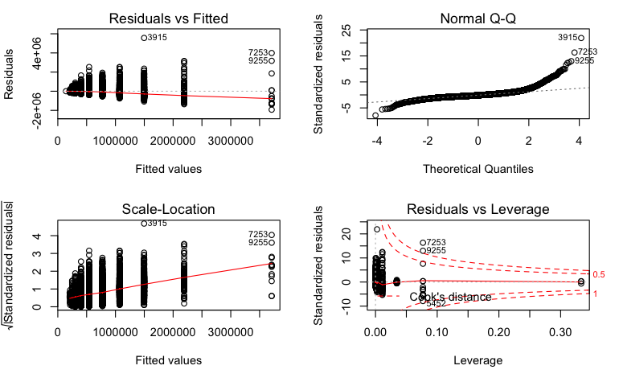

```r
par(mfrow = c(2, 2))
plot(mod1b)
```

SECOND PREDICTOR

```r
houses_resid <- houses_tidy %>%
  add_residuals(mod1b) %>%
  select(-c("price", "grade"))

houses_resid_numeric <- houses_resid %>%
  select_if(is.numeric)

houses_resid_nonnumeric <- houses_resid %>%
  select_if(function(x) !is.numeric(x))

houses_resid_nonnumeric$resid <- houses_resid$resid
```

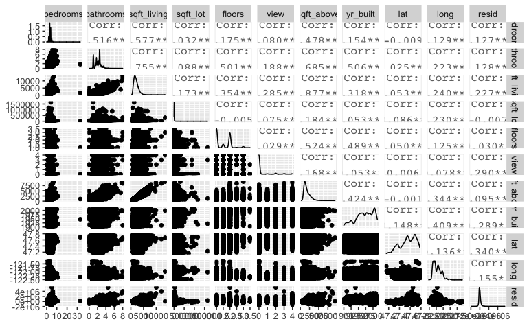

```r
ggpairs(houses_resid_numeric)
```

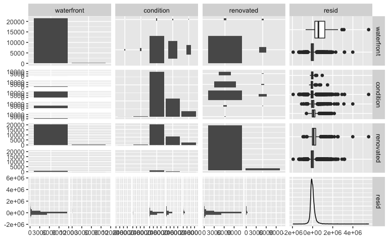

```r
ggpairs(houses_resid_nonnumeric)
```

lat has highest correlation with residuals, but, again, waterfront still looks pretty promising. Try both…

```r
mod2a <- lm(price ~ grade + lat, data = houses_tidy)
summary(mod2a)
```

```
Call:
lm(formula = price ~ grade + lat, data = houses_tidy)

Residuals:
     Min       1Q   Median       3Q      Max
-1863783  -112379   -28181    67454  5533910

Coefficients:
             Estimate Std. Error t value Pr(>|t|)
(Intercept) -29949769     610666 -49.044  < 2e-16 ***
grade3         187923     276126   0.681 0.496151
grade4          95367     243212   0.392 0.694978
grade5         126354     239618   0.527 0.597980
grade6         158453     239183   0.662 0.507673
grade7         246275     239138   1.030 0.303093
grade8         378635     239144   1.583 0.113369
grade9         603010     239170   2.521 0.011701 *
grade10        891752     239230   3.728 0.000194 ***
grade11       1311124     239425   5.476  4.4e-08 ***
grade12       2007093     240450   8.347  < 2e-16 ***
grade13       3502099     248154  14.113  < 2e-16 ***
lat            633100      11822  53.554  < 2e-16 ***
---
Signif. codes:  0 ‘***’ 0.001 ‘**’ 0.01 ‘*’ 0.05 ‘.’ 0.1 ‘ ’ 1

Residual standard error: 239100 on 21600 degrees of freedom
Multiple R-squared:  0.576, Adjusted R-squared:  0.5758
F-statistic:  2445 on 12 and 21600 DF,  p-value: < 2.2e-16
```

```r
mod2b <- lm(price ~ grade + waterfront, data = houses_tidy)
summary(mod2b)
```

```
Call:
lm(formula = price ~ grade + waterfront, data = houses_tidy)

Residuals:
     Min       1Q   Median       3Q      Max
-1929615  -132969   -32393    91481  4778940

Coefficients:
               Estimate Std. Error t value Pr(>|t|)
(Intercept)      142000     244366   0.581   0.5612
grade3            63667     282169   0.226   0.8215
grade4            72381     248543   0.291   0.7709
grade5            92834     244870   0.379   0.7046
grade6           155043     244426   0.634   0.5259
grade7           258469     244379   1.058   0.2902
grade8           395393     244386   1.618   0.1057
grade9           623595     244413   2.551   0.0107 *
grade10          909321     244474   3.719   0.0002 ***
grade11         1313326     244674   5.368 8.06e-08 ***
grade12         1947993     245731   7.927 2.35e-15 ***
grade13         3567615     253590  14.068  < 2e-16 ***
waterfrontTRUE   828234      19363  42.773  < 2e-16 ***
---
Signif. codes:  0 ‘***’ 0.001 ‘**’ 0.01 ‘*’ 0.05 ‘.’ 0.1 ‘ ’ 1

Residual standard error: 244400 on 21600 degrees of freedom
Multiple R-squared:  0.5572,    Adjusted R-squared:  0.557
F-statistic:  2265 on 12 and 21600 DF,  p-value: < 2.2e-16
```

```
not plotting observations with leverage one:
  19453
```

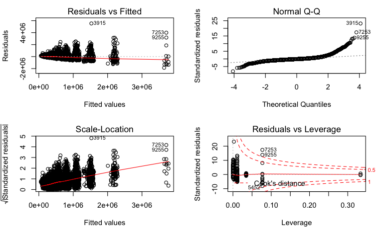

```r
par(mfrow = c(2, 2))
plot(mod2a)
```

THIRD PREDICTOR

```r
houses_resid <- houses_tidy %>%
  add_residuals(mod2a) %>%
  select(-c("price", "grade", "lat"))

houses_resid_numeric <- houses_resid %>%
  select_if(is.numeric)

houses_resid_nonnumeric <- houses_resid %>%
  select_if(function(x) !is.numeric(x))

houses_resid_nonnumeric$resid <- houses_resid$resid
```

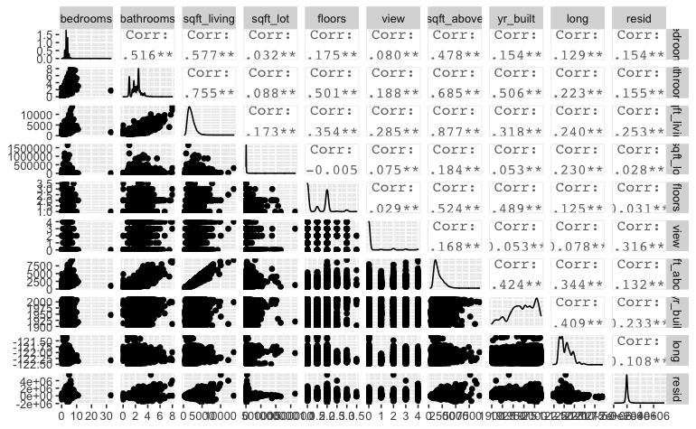

```r
ggpairs(houses_resid_numeric)
```

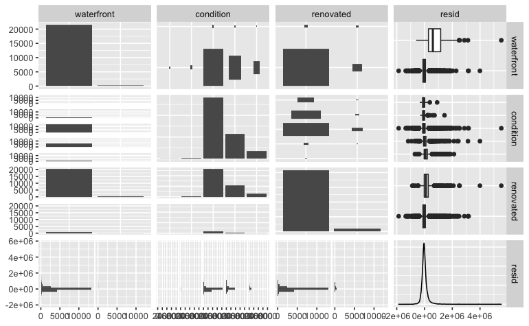

```r
ggpairs(houses_resid_nonnumeric)
```

Now view has strongest correlation with residuals, but also compare against model with waterfront.

```r
mod3a <- lm(price ~ grade + lat + view, data = houses_tidy)
summary(mod3a)
```

```
Call:
lm(formula = price ~ grade + lat + view, data = houses_tidy)

Residuals:
     Min       1Q   Median       3Q      Max
-1665265  -105866   -21393    69623  5429667

Coefficients:
             Estimate Std. Error t value Pr(>|t|)
(Intercept) -30514024     576750 -52.907  < 2e-16 ***
grade3         190253     260743   0.730 0.465607
grade4          81058     229663   0.353 0.724133
grade5         112154     226269   0.496 0.620134
grade6         148515     225858   0.658 0.510827
grade7         235345     225815   1.042 0.297328
grade8         351873     225822   1.558 0.119203
grade9         556584     225848   2.464 0.013731 *
grade10        821118     225907   3.635 0.000279 ***
grade11       1200228     226097   5.308 1.12e-07 ***
grade12       1832950     227080   8.072 7.28e-16 ***
grade13       3303587     234361  14.096  < 2e-16 ***
lat            644972      11166  57.764  < 2e-16 ***
view           106862       2086  51.234  < 2e-16 ***
---
Signif. codes:  0 ‘***’ 0.001 ‘**’ 0.01 ‘*’ 0.05 ‘.’ 0.1 ‘ ’ 1

Residual standard error: 225800 on 21599 degrees of freedom
Multiple R-squared:  0.6219,    Adjusted R-squared:  0.6217
F-statistic:  2733 on 13 and 21599 DF,  p-value: < 2.2e-16
```

```
not plotting observations with leverage one:
  19453
```

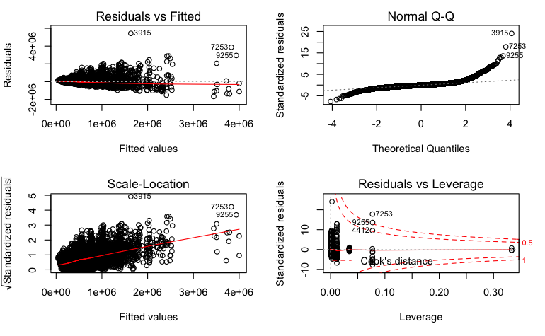

```r
par(mfrow = c(2, 2))
plot(mod3a)
```

FOURTH PREDICTION

```r
houses_resid <- houses_tidy %>%
  add_residuals(mod3a) %>%
  select(-c("price", "grade", "lat", "view"))

houses_resid_numeric <- houses_resid %>%
  select_if(is.numeric)

houses_resid_nonnumeric <- houses_resid %>%
  select_if(function(x) !is.numeric(x))

houses_resid_nonnumeric$resid <- houses_resid$resid
```

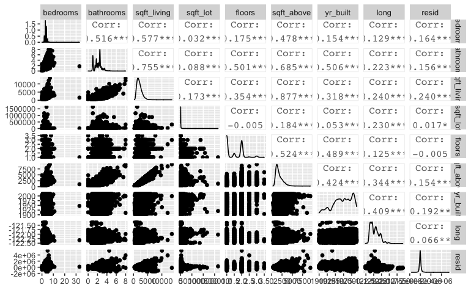

```r
ggpairs(houses_resid_numeric)
```

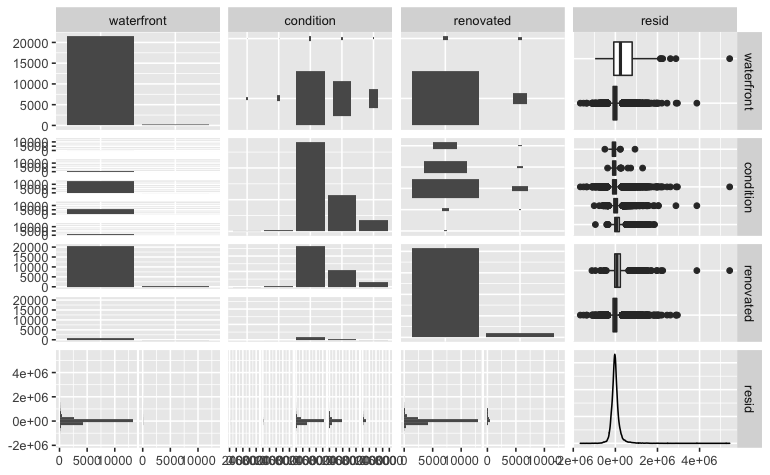

```r
ggpairs(houses_resid_nonnumeric)
```

sqft_living has highest correlation with residuals. Let’s test against all remaining categorical predictors:

```r
mod4a <- lm(price ~ grade + lat + view + sqft_living, data = houses_tidy)
summary(mod4a)
```

```
Call:
lm(formula = price ~ grade + lat + view + sqft_living, data = houses_tidy)

Residuals:
     Min       1Q   Median       3Q      Max
-1721458   -98010   -13893    65314  4594554

Coefficients:
              Estimate Std. Error t value Pr(>|t|)
(Intercept) -3.200e+07  5.333e+05 -60.005  < 2e-16 ***
grade3       1.501e+05  2.409e+05   0.623  0.53310
grade4       2.858e+04  2.121e+05   0.135  0.89282
grade5       1.098e+04  2.090e+05   0.053  0.95811
grade6       1.435e+04  2.086e+05   0.069  0.94516
grade7       2.584e+04  2.086e+05   0.124  0.90141
grade8       6.978e+04  2.086e+05   0.334  0.73804
grade9       1.743e+05  2.087e+05   0.835  0.40375
grade10      3.438e+05  2.088e+05   1.646  0.09974 .
grade11      5.968e+05  2.091e+05   2.854  0.00432 **
grade12      1.077e+06  2.101e+05   5.125    3e-07 ***
grade13      2.247e+06  2.172e+05  10.349  < 2e-16 ***
lat          6.753e+05  1.033e+04  65.403  < 2e-16 ***
view         9.158e+04  1.943e+03  47.134  < 2e-16 ***
sqft_living  1.503e+02  2.466e+00  60.957  < 2e-16 ***
---
Signif. codes:  0 ‘***’ 0.001 ‘**’ 0.01 ‘*’ 0.05 ‘.’ 0.1 ‘ ’ 1

Residual standard error: 208600 on 21598 degrees of freedom
Multiple R-squared:  0.6774,    Adjusted R-squared:  0.6772
F-statistic:  3240 on 14 and 21598 DF,  p-value: < 2.2e-16
```

```r
mod4b <- lm(price ~ grade + lat + view + waterfront, data = houses_tidy)
summary(mod4b)
```

```
Call:
lm(formula = price ~ grade + lat + view + waterfront, data = houses_tidy)

Residuals:
     Min       1Q   Median       3Q      Max
-1713543  -105538   -20871    69842  4901827

Coefficients:
                Estimate Std. Error t value Pr(>|t|)
(Intercept)    -30758475     564698 -54.469  < 2e-16 ***
grade3            191262     255269   0.749 0.453709
grade4             84892     224841   0.378 0.705758
grade5            106294     221518   0.480 0.631345
grade6            147526     221116   0.667 0.504659
grade7            236375     221074   1.069 0.284985
grade8            354372     221081   1.603 0.108970
grade9            562139     221106   2.542 0.011016 *
grade10           823728     221164   3.725 0.000196 ***
grade11          1197915     221350   5.412 6.30e-08 ***
grade12          1804315     222314   8.116 5.07e-16 ***
grade13          3351868     229446  14.609  < 2e-16 ***
lat               650115      10932  59.466  < 2e-16 ***
view               80422       2217  36.273  < 2e-16 ***
waterfrontTRUE    582422      19024  30.615  < 2e-16 ***
---
Signif. codes:  0 ‘***’ 0.001 ‘**’ 0.01 ‘*’ 0.05 ‘.’ 0.1 ‘ ’ 1

Residual standard error: 221100 on 21598 degrees of freedom
Multiple R-squared:  0.6377,    Adjusted R-squared:  0.6374
F-statistic:  2715 on 14 and 21598 DF,  p-value: < 2.2e-16
```

```r
mod4c <- lm(price ~ grade + lat + view + condition, data = houses_tidy)
summary(mod4c)
```

```
Call:
lm(formula = price ~ grade + lat + view + condition, data = houses_tidy)

Residuals:
     Min       1Q   Median       3Q      Max
-1665132  -105472   -18392    71578  5447648

Coefficients:
              Estimate Std. Error t value Pr(>|t|)
(Intercept) -3.043e+07  5.673e+05 -53.640  < 2e-16 ***
grade3       1.472e+05  2.595e+05   0.567 0.570486
grade4       6.481e+04  2.291e+05   0.283 0.777293
grade5       7.656e+04  2.258e+05   0.339 0.734605
grade6       1.165e+05  2.257e+05   0.516 0.605628
grade7       2.090e+05  2.257e+05   0.926 0.354406
grade8       3.359e+05  2.257e+05   1.488 0.136720
grade9       5.476e+05  2.257e+05   2.426 0.015270 *
grade10      8.154e+05  2.258e+05   3.612 0.000305 ***
grade11      1.199e+06  2.260e+05   5.307 1.12e-07 ***
grade12      1.834e+06  2.269e+05   8.082 6.69e-16 ***
grade13      3.310e+06  2.339e+05  14.148  < 2e-16 ***
lat          6.432e+05  1.098e+04  58.552  < 2e-16 ***
view         1.017e+05  2.058e+03  49.425  < 2e-16 ***
condition2  -4.275e+02  4.466e+04  -0.010 0.992363
condition3  -6.453e+03  4.154e+04  -0.155 0.876556
condition4   5.758e+04  4.158e+04   1.385 0.166054
condition5   1.349e+05  4.180e+04   3.226 0.001258 **
---
Signif. codes:  0 ‘***’ 0.001 ‘**’ 0.01 ‘*’ 0.05 ‘.’ 0.1 ‘ ’ 1

Residual standard error: 221800 on 21595 degrees of freedom
Multiple R-squared:  0.6352,    Adjusted R-squared:  0.635
F-statistic:  2212 on 17 and 21595 DF,  p-value: < 2.2e-16
```

```r
mod4d <- lm(price ~ grade + lat + view + renovated, data = houses_tidy)
summary(mod4d)
```

```
Call:
lm(formula = price ~ grade + lat + view + renovated, data = houses_tidy)

Residuals:
     Min       1Q   Median       3Q      Max
-1637628  -105101   -19410    70577  5280904

Coefficients:
               Estimate Std. Error t value Pr(>|t|)
(Intercept)   -30179084     571198 -52.835  < 2e-16 ***
grade3           188870     258132   0.732 0.464372
grade4            75932     227363   0.334 0.738407
grade5           108602     224003   0.485 0.627808
grade6           141362     223596   0.632 0.527250
grade7           229992     223554   1.029 0.303586
grade8           346281     223561   1.549 0.121413
grade9           550447     223587   2.462 0.013828 *
grade10          817501     223645   3.655 0.000257 ***
grade11         1199432     223833   5.359 8.47e-08 ***
grade12         1835525     224806   8.165 3.39e-16 ***
grade13         3275946     232018  14.119  < 2e-16 ***
lat              637925      11059  57.684  < 2e-16 ***
view             102285       2076  49.261  < 2e-16 ***
renovatedTRUE    159554       7606  20.979  < 2e-16 ***
---
Signif. codes:  0 ‘***’ 0.001 ‘**’ 0.01 ‘*’ 0.05 ‘.’ 0.1 ‘ ’ 1

Residual standard error: 223500 on 21598 degrees of freedom
Multiple R-squared:  0.6295,    Adjusted R-squared:  0.6292
F-statistic:  2621 on 14 and 21598 DF,  p-value: < 2.2e-16
```

```
not plotting observations with leverage one:
  19453
```

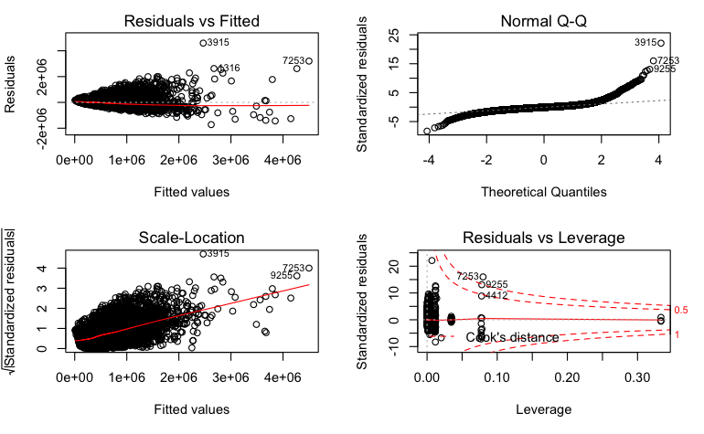

```r
par(mfrow = c(2, 2))
plot(mod4a)
```

```r
houses_resid <- houses_tidy %>%
  add_residuals(mod4a) %>%
  select(- price)
```

Our final model in terms of main effects is: price ~ grade + lat + view + sqft_living